# 02 · Risk model, prizes and the monthly schedule

**Project:** Optimizing the Order and Execution of Periodic Tobacco Retail Inspections in Pittsburgh, PA **Purpose:** implement the Proposed Alternative end to end on the data prepared in notebook 01 and `docs/process/02_Data_Acquisition_Memo.md`, test whether it beats the comparators, and say plainly where current information makes a piece infeasible or meaningless.

Every quoted passage below is the team's Proposed Alternative, unchanged; the "Implementation" notes underneath are this notebook's own text.

**Evidence labels used on every result**

- *observed-sample*: computed from real FDA/Synar records, but only for stores that were inspected (selection bias);
- *simulated*: computed on a synthetic truth, so it shows what a policy does *if the model is right*;
- *assumed*: depends on a parameter no data identifies (deterrence strength, purchaser response, service time).

Reusable code lives in `src/tobacco_inspect/`; this notebook is the narrative. Set `FULL = True` below to rerun the slow experiments (about 15 minutes); otherwise saved results in `outputs/` are loaded.

```python
import warnings
from pathlib import Path

import matplotlib.pyplot as plt
import numpy as np
import pandas as pd

from tobacco_inspect import pipeline
from tobacco_inspect.config import load_config
from tobacco_inspect.data import synar
from tobacco_inspect.eval import backtest, equity, experiments, metrics
from tobacco_inspect.model import history, risk

warnings.filterwarnings("ignore", category=FutureWarning)
pd.set_option("display.max_columns", 40, "display.width", 160)
cfg = load_config()
OUT = cfg.path("outputs")
FULL = False  # True reruns Gate B and the simulations (slow); False loads saved results if present
RNG = np.random.default_rng(cfg.seed)
```

## 1. Problem framing: a budgeted prize-collecting tour

**Proposal, paragraph 1** (quoted from the Proposed Alternative)

> We suggest a modified version of the Prize-Collecting Traveling-Salesman Problem (PCTSP) in order to more effectively prioritize Pittsburgh’s nicotine policy checks over random sampling. The Prize-Collecting TSP, in contrast to the traditional TSP, does not seek to reach all network nodes; rather, it seeks to maximize the total benefit (prizes) collected from the nodes accessed. Paul et al.’s “Budgeted” variation places further constraints on this model, forcing it to produce maximum benefit within a provided capacity. As enforcement infrastructure, staffing, and related monetary costs are all limited, we believe that a budgeted variant is most appropriate.

**Implementation.** The prize is a risk score per store; the budget is the number of inspections and the working day of each team. `solve_team_orienteering` (`model/orienteering.py`) is the budgeted PCTSP in team form: route slots (team x day), at most one visit per store, a total budget B, a time limit per route, coverage floors.

**Reality check on scale.** The budget is small: the cell below derives it from the data. If the budget binds long before the working day does, the "traveling" part of the problem has little to optimize. Section 5 measures when that changes.

```python
cap = cfg.capacity
fy = pd.read_csv(cfg.path("interim") / "oce_pa_by_fiscal_year.csv")
print(f"City-limits undercover checks per fiscal year (FDA OCE files):")
print(fy[["fy", "up_checks", "city_up_checks", "city_violations"]].tail(8).to_string(index=False))
stops_per_day = (cap.daily_budget_minutes - 30) / (cap.service_minutes + 10)  # rough: 20 min service + ~10 min drive
print(f"\nHorizon {cap.horizon_weeks} weeks, {cap.cycles} monthly cycles, budget {cap.budget_inspections} per horizon "
      f"= {cap.cycle_budget} per cycle")
print(f"Team-days available per cycle: {cap.teams * cap.cycle_days}; one team-day fits about {stops_per_day:.0f} stops")
print(f"=> a cycle needs about {cap.cycle_budget / stops_per_day:.1f} team-days out of {cap.teams * cap.cycle_days}: the budget binds, not time.")
```

```
City-limits undercover checks per fiscal year (FDA OCE files):
  fy  up_checks  city_up_checks  city_violations
2019       4620             123                2
2020       1924              15                1
2021         60               3                0
2022       1752              39               17
2023       2330              42               13
2024       3471              71               24
2025       2988              22                3
2026       2342               4                2

Horizon 13 weeks, 3 monthly cycles, budget 11 per horizon = 4 per cycle
Team-days available per cycle: 40; one team-day fits about 15 stops
=> a cycle needs about 0.3 team-days out of 40: the budget binds, not time.
```

## 2. Targeted and untargeted firms: does prior noncompliance predict violations?

**Proposal, paragraph 2** (quoted from the Proposed Alternative)

> Referencing findings in the environmental protection space (Harrington 1988), regulatory agencies can still achieve high policy compliance through appropriate division of firms into “untargeted” and “targeted” regulatory groups. Firms are deemed risky and thus “targeted” based on prior noncompliance, whereas historically compliant firms are rewarded for good behavior with less severe scrutiny, becoming “untargeted.” Carrying Harrington’s findings to the tobacco regulation space, we assign tobacco sellers with higher potential negative externalities, greater time since past inspection, and prior noncompliance with higher risk scores. Risk scores become the collected “prizes”, attempting to minimize the negative consequences of noncompliance.

**Implementation.**

- *Targeted vs untargeted* (`model/harrington.py`): a store is targeted when it has a violation in the last 24 months. The enforcement state follows FDA's real escalation schedule (violations in 12/24/36-month windows, HHS-OIG OEI-01-20-00240), not an invented state space. How strongly an inspection changes behavior (`prize.lambda_deterrence`) is **assumed**; no data identifies it.
- *Prior noncompliance and time since past inspection* (`model/history.py`): leakage-safe features computed only from records decided at least 30 days before the check. Decision date is the clock because inspection dates are missing for about 90% of records.
- *Risk score* (`model/risk.py`): L2 logistic regression trained on all Pennsylvania undercover checks (49k), then applied to Pittsburgh. Pittsburgh alone is too small to evaluate (174 city checks and 57 violations over the four test years, as few as 3 in one year).

**Gate A** asks whether this beats the comparators, replaying fiscal years 2022-2025 (train on earlier years, test on year t). Replay can only score stores that were actually inspected, so its lift is *observed-sample*.

```python
fit = pipeline.fit(cfg, write=False)
model, bt, scores = fit["model"], fit["backtest"], fit["scores"]
print(f"Model: C={model.c}, trained on {model.n_train:,} checks with {model.positives:,} violations")
for subset in ["PA", "Pittsburgh city"]:
    for frac in (0.1, 0.2):
        tab = backtest.pooled_lift(bt, subset, frac)
        print(f"\n{subset}, top {int(frac*100)}% of the ranking - mean over test years (observed-sample)")
        print(tab.round(3).to_string())
```

```
Model: C=1.0, trained on 49,032 checks with 7,217 violations

PA, top 10% of the ranking - mean over test years (observed-sample)
                         auc   lift  lift_lo  lift_hi
scorer
prior_violators_first  0.565  1.493    1.227    1.802
model                  0.718  1.470    1.225    1.771
days_since_check       0.579  1.470    1.113    1.654
status_quo_followup    0.521  1.370    1.053    1.630
random                 0.492  1.009    0.761    1.232

PA, top 20% of the ranking - mean over test years (observed-sample)
                         auc   lift  lift_lo  lift_hi
scorer
model                  0.718  1.531    1.350    1.730
prior_violators_first  0.565  1.458    1.286    1.643
days_since_check       0.579  1.318    1.182    1.540
status_quo_followup    0.521  1.138    0.999    1.347
random                 0.492  0.943    0.779    1.114

Pittsburgh city, top 10% of the ranking - mean over test years (observed-sample)
                         auc   lift  lift_lo  lift_hi
scorer
days_since_check       0.589  1.698    0.438    2.328
random                 0.535  1.008    0.000    3.176
prior_violators_first  0.512  0.843    0.000    1.826
model                  0.743  0.536    0.232    2.882
status_quo_followup    0.462  0.308    0.000    2.040

Pittsburgh city, top 20% of the ranking - mean over test years (observed-sample)
                         auc   lift  lift_lo  lift_hi
scorer
model                  0.743  1.474    0.383    3.138
days_since_check       0.589  1.376    0.709    1.959
random                 0.535  1.240    0.089    2.386
status_quo_followup    0.462  0.928    0.030    2.381
prior_violators_first  0.512  0.825    0.257    1.880
```

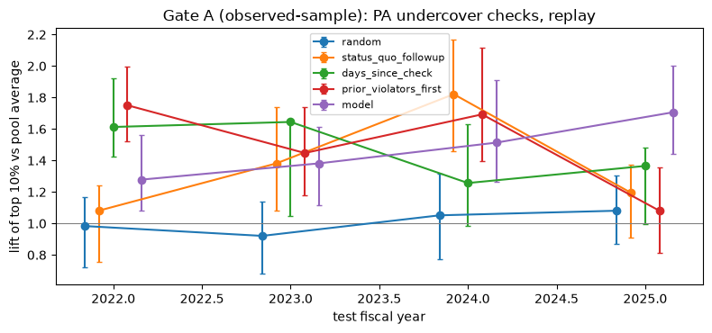

```python
# Lift at top 10% by test year, PA-wide, with bootstrap intervals
sub = bt[(bt.subset == "PA") & (bt.frac == 0.1)]
fig, ax = plt.subplots(figsize=(8, 3.8))
order = ["random", "status_quo_followup", "days_since_check", "prior_violators_first", "model"]
for k, name in enumerate(order):
    d = sub[sub.scorer == name].sort_values("fy")
    ax.errorbar(d.fy + (k - 2) * 0.08, d.lift, yerr=[(d.lift - d.lift_lo).clip(lower=0), (d.lift_hi - d.lift).clip(lower=0)],
                fmt="o-", capsize=2, label=name)
ax.axhline(1, color="grey", lw=0.8)
ax.set_xlabel("test fiscal year"); ax.set_ylabel("lift of top 10% vs pool average")
ax.set_title("Gate A (observed-sample): PA undercover checks, replay"); ax.legend(fontsize=8)
plt.tight_layout(); plt.show()
```

**Reading Gate A.** At the PA level the model's ranking beats random with intervals clear of 1. The prior-violators-first rule is about as good in the very top of the ranking; the model's edge is across the whole ranking (higher AUC), which comes from combining outlet type (the largest coefficients) with the history and time-since-check terms. FDA's follow-up rule is the weakest informative comparator. Pittsburgh-only replay is too thin to say anything (intervals span 0 to 3). *All observed-sample.*

### Random-sample benchmark: Synar

The 2025 PA Synar report (a probability sample of cigarette retailers) is the only random baseline available. Two uses:

1. *Is the status quo already better than random?* Compare FDA's yearly undercover violation rate with Synar's confidence band.
2. *Prior-shift calibration:* the model is trained on an enriched sample, so its mean is rescaled to Synar's Allegheny rate (26.0%, 95% CI 17.3-34.7) to approximate P(violation | store exists). Caveats: Synar is cigarettes only (OCE includes cigars and ENDS and follow-up checks); Synar's yearly bounds here are read off a chart (approximate); Allegheny is one summer, n = 100.

```python
enrich = backtest.synar_enrichment(pd.read_csv(cfg.path("interim") / "oce_pa_by_fiscal_year.csv"))
print(enrich[["fy", "up_checks", "violation_rate", "synar_lower", "synar_upper", "ratio_to_synar",
              "above_synar_band", "below_synar_band"]].round(3).to_string(index=False))
al, lo, hi = synar.allegheny_rate()
print(f"\nSynar Allegheny: {al:.1%} ({lo:.1%}-{hi:.1%}), n=100 completed")
city = fy[["fy", "city_up_checks", "city_violations", "city_violation_rate"]].tail(6)
print("\nPittsburgh city FDA undercover rate by fiscal year (observed-sample):")
print(city.to_string(index=False))
r = scores[scores.retail_license]
print(f"\nModel mean p: raw {r.p_raw.mean():.1%} -> calibrated {r.p.mean():.1%} (logit shift {fit['calibration_shift']:+.2f})")
```

```
  fy  up_checks  violation_rate  synar_lower  synar_upper  ratio_to_synar  above_synar_band  below_synar_band
2016       4770           0.131         0.08         0.12           1.310              True             False
2017       4067           0.189         0.06         0.09           2.520              True             False
2018       3609           0.115         0.07         0.11           1.278              True             False
2019       4620           0.162         0.06         0.10           2.025              True             False
2020       1924           0.120         0.14         0.19           0.727             False              True
2021         60           0.017         0.14         0.19           0.103             False              True
2022       1752           0.291         0.14         0.19           1.764              True             False
2023       2330           0.196         0.09         0.14           1.704              True             False
2024       3471           0.112         0.11         0.16           0.830             False             False
2025       2988           0.176         0.13         0.18           1.135             False             False

Synar Allegheny: 26.0% (17.3%-34.7%), n=100 completed

Pittsburgh city FDA undercover rate by fiscal year (observed-sample):
  fy  city_up_checks  city_violations  city_violation_rate
2021               3                0                0.000
2022              39               17                0.436
2023              42               13                0.310
2024              71               24                0.338
2025              22                3                0.136
2026               4                2                0.500

Model mean p: raw 16.3% -> calibrated 25.6% (logit shift +0.61)
```

**Outlet-type check.** Synar Table 8 gives violation rates by outlet type (dollar stores 2.9%, supermarkets 6.6%, chain convenience/gas 13.9%, tobacco shops 22.3%, independent convenience 23.7%). The model should order types the same way.

```python
frame = history.build_training_frame(pd.read_csv(cfg.path("processed") / "oce_pa_checks.csv.gz",
                                                 dtype={"Zip": str}, parse_dates=["decision_date_parsed"]).assign(up_involved=True),
                                     lag_days=cfg.raw["risk"]["lag_days"])
eff = risk.outlet_effects(frame, model.predict(frame)).set_index("outlet_type")
syn = synar.outlet_type_rates().set_index("outlet_type")[["rate"]].rename(columns={"rate": "synar_2025"})
cmp = eff.join(syn).round(3)
print(cmp.sort_values("mean_p").to_string())
ok = cmp.dropna()
print(f"\nSpearman rank correlation, model vs Synar (types with a Synar rate, n={len(ok)}): "
      f"{ok['mean_p'].corr(ok['synar_2025'], method='spearman'):.2f}")
coef = fit["coefficients"]
print("\nLargest coefficients (standardized features):")
print(pd.concat([coef.head(4), coef.tail(5)]).round(3).to_string())
```

```
                             n  mean_p  observed  synar_2025
outlet_type
pharmacy                  3015   0.047     0.046         NaN
dollar_store              2795   0.074     0.074       0.029
supermarket               2903   0.087     0.086       0.066
beer_distributor          2269   0.105     0.105       0.083
other                     7564   0.128     0.128         NaN
convenience_gas          12274   0.141     0.141       0.139
bar_tavern                 508   0.147     0.144         NaN
news                       368   0.163     0.168         NaN
convenience_independent  12195   0.198     0.198       0.237
tobacco_shop              2026   0.205     0.204       0.223
restaurant_deli           3115   0.228     0.229         NaN

Spearman rank correlation, model vs Synar (types with a Synar rate, n=6): 0.94

Largest coefficients (standardized features):
cat__outlet_type_pharmacy           -0.936
cat__outlet_type_dollar_store       -0.452
cat__outlet_type_beer_distributor   -0.428
num__log_prior_checks               -0.352
cat__outlet_type_restaurant_deli     0.301
num__log_prior_viol                  0.324
num__log_days_since_check            0.331
num__has_prior_viol                  0.348
num__log_days_since_viol             0.353
```

## 3. Externalities: proximity to vulnerable sites as the exposure proxy

**Proposal, paragraph 3** (quoted from the Proposed Alternative)

> In order to characterize noncompliance as an externality-producing and thus quantifiable process, we draw on previous literature assessing the downstream healthcare costs associated with tobacco use. Tobacco usage has a well-documented correlation with negative health outcomes, including but not limited to carcinogenic impact, addictive behaviors, and declines in mental health. In lieu of per-store tobacco purchase volumes, we use proximity to vulnerable sites (schools, community centers, etc.) as a proxy for measuring externalities.

**Implementation** (`model/prize.py`). No per-store sales volumes or health-cost data exist, so exposure h_i is a proxy for the externality, built from (a) proximity to vulnerable sites: NCES public and private schools plus OpenStreetMap libraries, community centres, childcare, playgrounds and parks ("community centers, etc." is only available through OSM), (b) tract youth share, shrunk toward the city median where the ACS margin of error is large, and (c) historical severity of past penalties. Weights are in `config/default.yaml`. The prize is `r_i = h_i * p_i + lambda * D_i`, where D_i (recency x state weight) carries the proposal's "greater time since past inspection" and `lambda` is assumed. The score is unit-free; it is **not** a dollar estimate of harm. Caveat: historical severity partly double counts violations already in p_i.

```python
r = scores[scores.retail_license].copy()
print(r[["p", "h", "site", "youth", "severity", "deterrence", "prize"]].describe().round(3).T)
top = r.sort_values("prize", ascending=False).drop_duplicates("location_key").head(10)
print("\nTop 10 by prize (one row per location):")
print(top[["trade_name", "street_address", "outlet_type", "p", "h", "deterrence", "prize", "viol_12m",
           "days_since_check"]].round(3).to_string(index=False))
uni = pipeline.load_universe(cfg)
print(f"\nTract youth-share estimates flagged unreliable (MOE > 50% of estimate): "
      f"{uni[uni.retail_license].acs_youth_share_unreliable.mean():.0%} of retail licenses")
```

```
            count   mean    std    min    25%    50%    75%    max
p           392.0  0.256  0.113  0.026  0.162  0.277  0.349  0.549
h           392.0  0.310  0.092  0.058  0.257  0.312  0.371  0.629
site        392.0  0.269  0.182  0.002  0.121  0.250  0.386  0.835
youth       392.0  0.635  0.228  0.000  0.638  0.717  0.761  1.000
severity    392.0  0.040  0.109  0.000  0.000  0.000  0.000  1.000
deterrence  392.0  0.272  0.096  0.073  0.250  0.250  0.250  0.800
prize       392.0  0.148  0.060  0.025  0.107  0.138  0.174  0.430

Top 10 by prize (one row per location):
                   trade_name        street_address             outlet_type     p     h  deterrence  prize  viol_12m  days_since_check
             BROOKLINE SUNOCO    533 BROOKLINE BLVD         convenience_gas 0.438 0.524         0.8  0.430         0             607.0
                  FORBES DELI       3801 FORBES AVE         restaurant_deli 0.503 0.484         0.6  0.393         0             850.0
                        STORE        214 N CRAIG ST convenience_independent 0.549 0.434         0.6  0.388         0             863.0
                    MAHER INC   5880 1/2 FORBES AVE                   other 0.295 0.629         0.8  0.385         0             575.0
 OAKLAND CONVENIENCE MART LLC          3604 5TH AVE convenience_independent 0.488 0.380         0.8  0.385         0             502.0
BROOKLYN FOODMART CORPORATION      1500 LINCOLN AVE convenience_independent 0.479 0.467         0.6  0.374         0             835.0
               BP GAS STATION 910 SAW MILL RUN BLVD         convenience_gas 0.422 0.404         0.6  0.321         0             703.0
              819 LIBERTY LLC       819 LIBERTY AVE                   other 0.342 0.461         0.6  0.308         0             653.0
         BROOKLINE MINI MARTT   1001 BROOKLINE BLVD convenience_independent 0.391 0.328         0.6  0.278         0             651.0
           K STOP CONVENIENCE      2903 BRIGHTON RD convenience_independent 0.334 0.374         0.6  0.275         0             688.0

Tract youth-share estimates flagged unreliable (MOE > 50% of estimate): 42% of retail licenses
```

```python
# Sensitivity of the ranking to the exposure weights and lambda (overlap of the top-B stores)
cand = pipeline.unique_locations(r)
B = 11
base = set(cand.nlargest(B, "prize").index)
rows = []
variants = {"site-heavy": (0.7, 0.15, 0.15), "youth-heavy": (0.15, 0.7, 0.15), "severity-heavy": (0.15, 0.15, 0.7),
            "no severity": (0.5, 0.5, 0.0), "equal": (1/3, 1/3, 1/3)}
lam0 = cfg.prize["lambda_deterrence"]
for name, w in variants.items():
    h2 = w[0] * cand["site"] + w[1] * cand["youth"] + w[2] * cand["severity"]
    pr = h2 * cand["p"] + lam0 * cand["deterrence"]
    rows.append({"variant": name, "overlap_top_B": len(base & set(pr.nlargest(B).index))})
for lam in (0.0, 0.1, 0.25, 0.5):
    pr = cand["h"] * cand["p"] + lam * cand["deterrence"]
    rows.append({"variant": f"lambda={lam}", "overlap_top_B": len(base & set(pr.nlargest(B).index))})
print(pd.DataFrame(rows).to_string(index=False))
print(f"(overlap with the baseline top {B}; assumed parameters, so the schedule should never be read as sensitive-free)")
```

```
       variant  overlap_top_B
    site-heavy              7
   youth-heavy              9
severity-heavy             10
   no severity              7
         equal             11
    lambda=0.0              6
    lambda=0.1              8
   lambda=0.25             11
    lambda=0.5             11
(overlap with the baseline top 11; assumed parameters, so the schedule should never be read as sensitive-free)
```

## 4. Randomized monthly schedule and bounded rationality

**Proposal, paragraph 4** (quoted from the Proposed Alternative)

> We borrow elements from Stackelberg security games, as noncompliant retailers can be modeled as independent “attackers” under a nicotine regulation regime. In this view, regulatory agencies establish a “defensive” strategy in establishing a monthly schedule for compliance checks, whereas maliciously noncompliant sellers attempt to respond to this strategy. While we do not wish to overcomplicate our own model, we also recognize that, given these games’ historical implementation in MILP form, conceptual elements are compatible with general model TSPs. Most importantly, we view individual stores as acting from a perspective of bounded rationality: stores are aware they can be checked, but not necessarily that they will be checked.

**Implementation.** No data shows how Pittsburgh retailers respond to schedules, so a Stackelberg MILP is **not built**; the passage is used as the design rationale for randomization (`model/thompson.py`, `eval/simulate.py`):

- each monthly cycle samples every store's violation probability from a Beta distribution centered on the model's p_i (Thompson sampling, strength `kappa`), so the schedule is not a fixed list;
- a reserved random share is drawn like Synar's simple random Allegheny stratum;
- each store is visited at most once per horizon;
- *bounded rationality* enters the simulation as an assumed parameter rho: stores know how often they were recently checked, not when the next check comes, and cut violations in proportion to that frequency; deterrence delta is the effect of a check.

All results here are **simulated** with **assumed** delta and rho; the truth is the model's own calibrated p_i, so these runs show what each policy does if the model is right.

```python
cand_sim = pipeline.unique_locations(scores[scores.retail_license & scores.lon.notna()]).reset_index(drop=True)
saved = OUT / "simulation_policies.csv"
if FULL or not saved.exists():
    sim = experiments.policy_simulation(cfg, cand_sim, n_sims=60 if not FULL else 200)
    sim.to_csv(saved, index=False)
sim = pd.read_csv(saved)
piv = sim.pivot_table(index="policy", columns=["delta", "rho"], values="found_per_cycle").round(2)
print("Violations found per monthly cycle (4 stores per cycle); columns are (deterrence delta, exploitation rho)")
print(piv.to_string())
dist = sim[(sim.delta == 0) & (sim.rho == 0)].set_index("policy")["distinct_stores"].round(0)
print("\nDistinct stores visited over 36 cycles:"); print(dist.to_string())
```

```
Violations found per monthly cycle (4 stores per cycle); columns are (deterrence delta, exploitation rho)
delta                               0.00              0.25
rho                                  0.0   0.5   0.9   0.0   0.5
policy
prior_violators_first               1.72  0.88  0.21  0.77  0.41
prize_topB_at_most_once             1.36  1.36  1.36  1.36  1.36
prize_topB_fixed                    1.78  0.90  0.22  0.79  0.42
random                              1.02  1.01  1.01  1.01  1.01
risk_only_topB_fixed                2.08  1.06  0.26  0.93  0.49
status_quo_followup                 0.70  0.60  0.52  0.59  0.55
thompson_prize                      1.71  1.41  1.18  1.32  1.13
thompson_prize+random               1.54  1.34  1.17  1.27  1.13
thompson_prize+random_at_most_once  1.23  1.22  1.22  1.22  1.22

Distinct stores visited over 36 cycles:
policy
random                                118.0
status_quo_followup                    67.0
prior_violators_first                   4.0
risk_only_topB_fixed                    4.0
prize_topB_fixed                        4.0
prize_topB_at_most_once               144.0
thompson_prize                         30.0
thompson_prize+random                  54.0
thompson_prize+random_at_most_once    137.0
```

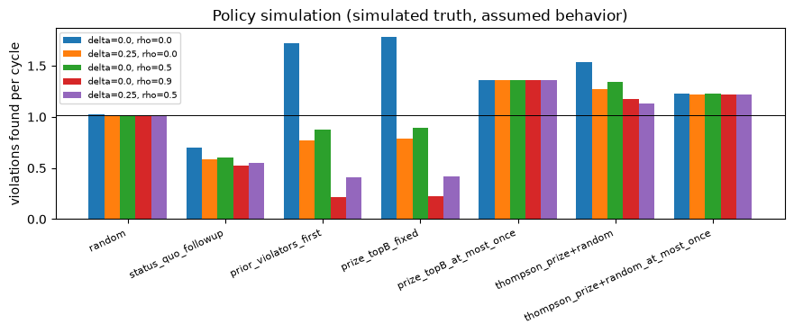

```python
fig, ax = plt.subplots(figsize=(9, 3.8))
pol = ["random", "status_quo_followup", "prior_violators_first", "prize_topB_fixed", "prize_topB_at_most_once",
       "thompson_prize+random", "thompson_prize+random_at_most_once"]
width = 0.16
scen = [(0.0, 0.0), (0.25, 0.0), (0.0, 0.5), (0.0, 0.9), (0.25, 0.5)]
for k, (d, rho) in enumerate(scen):
    vals = [sim[(sim.policy == p) & (sim.delta == d) & (sim.rho == rho)].found_per_cycle.mean() for p in pol]
    ax.bar(np.arange(len(pol)) + (k - 2) * width, vals, width, label=f"delta={d}, rho={rho}")
ax.set_xticks(range(len(pol))); ax.set_xticklabels(pol, rotation=25, ha="right", fontsize=8)
ax.set_ylabel("violations found per cycle"); ax.axhline(sim[sim.policy == "random"].found_per_cycle.mean(), color="k", lw=0.7)
ax.set_title("Policy simulation (simulated truth, assumed behavior)"); ax.legend(fontsize=7)
plt.tight_layout(); plt.show()
```

**Reading the simulation.** With no behavioral response, repeating the highest-scoring stores each month finds the most. As soon as stores react to inspection frequency (deterrence delta or exploitation rho), a fixed top-B list collapses, at strong exploitation below random. Policies that rotate through stores (at most once per horizon, with Thompson noise and a random share) stay about 1.2-1.4 times random across all assumptions. This is the practical content of the Stackelberg and bounded-rationality passage: do not publish a predictable list. `kappa` controls how much the sampled rate varies; a quick sensitivity follows.

```python
saved = OUT / "simulation_kappa.csv"
if FULL or not saved.exists():
    ks = experiments.kappa_sensitivity(cfg, cand_sim, n_sims=60)
    ks.to_csv(saved, index=False)
ks = pd.read_csv(saved)
cols = [c for c in ["kappa", "policy", "delta", "rho", "found_per_cycle", "distinct_stores", "random_share", "at_most_once"] if c in ks]
print(ks[cols].round(2).to_string(index=False))
print(f"\nconfig kappa = {cfg.raw['risk']['kappa']}")
```

```
 kappa                             policy  delta  rho  found_per_cycle  distinct_stores
     2              thompson_prize+random   0.00  0.0             1.49            59.24
     2 thompson_prize+random_at_most_once   0.00  0.0             1.19           136.65
     2              thompson_prize+random   0.25  0.5             1.20            59.24
     2 thompson_prize+random_at_most_once   0.25  0.5             1.18           136.65
     5              thompson_prize+random   0.00  0.0             1.53            54.27
     5 thompson_prize+random_at_most_once   0.00  0.0             1.22           136.78
     5              thompson_prize+random   0.25  0.5             1.13            54.27
     5 thompson_prize+random_at_most_once   0.25  0.5             1.22           136.78
    10              thompson_prize+random   0.00  0.0             1.59            46.66
    10 thompson_prize+random_at_most_once   0.00  0.0             1.25           136.69
    10              thompson_prize+random   0.25  0.5             1.07            46.66
    10 thompson_prize+random_at_most_once   0.25  0.5             1.24           136.69
    20              thompson_prize+random   0.00  0.0             1.62            41.99
    20 thompson_prize+random_at_most_once   0.00  0.0             1.29           137.11
    20              thompson_prize+random   0.25  0.5             0.99            41.99
    20 thompson_prize+random_at_most_once   0.25  0.5             1.29           137.11
   100              thompson_prize+random   0.00  0.0             1.62            39.75
   100 thompson_prize+random_at_most_once   0.00  0.0             1.30           137.18
   100              thompson_prize+random   0.25  0.5             0.89            39.75
   100 thompson_prize+random_at_most_once   0.25  0.5             1.30           137.18

config kappa = 5
```

## 5. Optimization: one monthly cycle, and when routing matters (Gate B)

**Implementation.** `pipeline.plan_cycle` samples prizes, reserves the random share, prunes to the top candidates plus the random picks and solves the team model on the OSM drive-time matrix. The comparator is `plan_ranked_batched`: rank by prize, take the top B, then batch by nearest neighbor. Solver: Gurobi (size-limited pip license) with automatic fallback to HiGHS if the model is too large. **Gate B** asks whether the MILP collects more prize than ranked+batched.

```python
schedule, summary, inst = pipeline.solve(cfg, scores=scores, write=False)
print(f"Travel times: {inst['travel_source']} (OSM drive network); candidates: {len(inst['cand'])} unique retail locations")
print(summary.to_string(index=False))
print(schedule[["cycle", "route", "team", "date", "stop", "store", "address", "p", "h", "prize", "random_share_pick"]]
      .round(3).to_string(index=False))
```

```
Travel times: osm (OSM drive network); candidates: 345 unique retail locations
 cycle  stores  routes  route_minutes  prize  heuristic_prize solver  status travel_source
     1       4       1          113.2 1.8313           1.8313 gurobi optimal           osm
     2       4       1          112.4 1.6305           1.6305 gurobi optimal           osm
     3       4       1          107.6 1.1702           1.1702 gurobi optimal           osm
 cycle  route  team       date  stop                              store              address     p     h  prize  random_share_pick
     1      1     1 2026-10-19     1                   BROOKLINE SUNOCO   533 BROOKLINE BLVD 0.438 0.524  0.430              False
     1      1     1 2026-10-19     2                  ADAN MARKET 2 INC 707 E WARRINGTON AVE 0.296 0.331  0.160               True
     1      1     1 2026-10-19     3                        FORBES DELI      3801 FORBES AVE 0.503 0.484  0.393              False
     1      1     1 2026-10-19     4                          MAHER INC  5880 1/2 FORBES AVE 0.295 0.629  0.385              False
     2      1     1 2026-11-30     1                         NS PUB INC      900 WESTERN AVE 0.280 0.236  0.129               True
     2      1     1 2026-11-30     2                    819 LIBERTY LLC      819 LIBERTY AVE 0.342 0.461  0.308              False
     2      1     1 2026-11-30     3                              STORE       214 N CRAIG ST 0.549 0.434  0.388              False
     2      1     1 2026-11-30     4      BROOKLYN FOODMART CORPORATION     1500 LINCOLN AVE 0.479 0.467  0.374              False
     3      1     1 2026-12-23     1               COMMUNITY MARKET #96     4401 LIBERTY AVE 0.372 0.386  0.206              False
     3      1     1 2026-12-23     2 KEYSTONE R&M LLC DBA KEYSTONE VAPO   215 S HIGHLAND AVE 0.107 0.403  0.106               True
     3      1     1 2026-12-23     3                   SMOKE CONNECTION      5804 FORBES AVE 0.401 0.472  0.252              False
     3      1     1 2026-12-23     4     STAR TRADING OF PITTSBURGH INC         5007 2ND AVE 0.277 0.433  0.183              False
```

```python
saved = OUT / "gate_b_sweep.csv"
if FULL or not saved.exists():
    sweep = experiments.gate_b_sweep(cfg, inst, budgets=(4, 8, 15, 25), route_counts=(1, 2),
                                     day_minutes=(480, 240, 120), time_limit=20 if not FULL else 60)
    sweep.to_csv(saved, index=False)
sweep = pd.read_csv(saved)
print(sweep[["budget", "n_routes", "day_minutes", "milp_prize", "heuristic_prize", "gain_pct", "status", "seconds"]].to_string(index=False))
real = sweep[(sweep.budget <= 8) & (sweep.n_routes >= 2) & (sweep.day_minutes >= 240)]
tight = sweep[(sweep.day_minutes <= 240) & (sweep.budget >= 15)]
print(f"\nAt the real operating point (budget <= 8, 2+ route slots, 4+ h days) mean MILP gain: {real.gain_pct.mean():.1f}%")
print(f"When time is scarce (budget >= 15, days <= 4 h) mean MILP gain: {tight.gain_pct.mean():.1f}% (some runs hit the time limit; gains are lower bounds on the optimum)")
```

```
 budget  n_routes  day_minutes  milp_prize  heuristic_prize  gain_pct       status  seconds
      4         1          480       1.618            1.618       0.0      optimal      0.1
      4         1          240       1.618            1.618       0.0      optimal      0.1
      4         1          120       1.618            1.618       0.0      optimal      0.1
      4         2          480       1.618            1.618       0.0      optimal      0.2
      4         2          240       1.618            1.618       0.0      optimal      0.2
      4         2          120       1.618            1.618       0.0      optimal      0.3
      8         1          480       3.055            3.055       0.0      optimal      0.3
      8         1          240       3.055            3.055       0.0      optimal      0.3
      8         1          120       1.937            1.937       0.0      optimal      0.4
      8         2          480       3.055            3.055       0.0      optimal      0.5
      8         2          240       3.055            3.055       0.0      optimal      0.6
      8         2          120       3.055            3.055       0.0      optimal      1.0
     15         1          480       5.147            5.147       0.0      optimal      0.6
     15         1          240       3.524            3.257       8.2      optimal     32.4
     15         1          120       1.937            1.937       0.0      optimal      0.6
     15         2          480       5.147            5.147       0.0      optimal      4.5
     15         2          240       5.147            5.147       0.0      optimal     10.5
     15         2          120       3.378            3.221       4.9 maxTimeLimit     60.9
     25         1          480       6.456            6.187       4.3 maxTimeLimit     60.5
     25         1          240       3.524            3.252       8.4      optimal     34.2
     25         1          120       1.937            1.814       6.7      optimal      0.8
     25         2          480       7.684            7.684       0.0 maxTimeLimit     60.5
     25         2          240       6.328            5.890       7.4 maxTimeLimit     60.7
     25         2          120       3.426            3.088      11.0 maxTimeLimit     61.0

At the real operating point (budget <= 8, 2+ route slots, 4+ h days) mean MILP gain: 0.0%
When time is scarce (budget >= 15, days <= 4 h) mean MILP gain: 5.8% (some runs hit the time limit; gains are lower bounds on the optimum)
```

**Gate B result.** At the budget the data supports (about 4 inspections per month), the MILP and the ranked+batched plan collect the same prize: routing has nothing to optimize because the budget binds long before the working day does. The MILP only pays off when time is scarce (larger budgets with short route slots or few team-days), where it gains roughly 4-11% in prize. So the recommendation is to ship a ranked, randomized list with simple batching, and keep the MILP for scale-up scenarios. The full decision-card formulation (all stores x 65 days x 2 teams) is infeasible under the size-limited Gurobi license and unnecessary; candidate pruning plus route slots replaces it.

## 6. Evaluation, equity and power

```python
# Policy metrics for the planned schedule vs baselines (model-based expected values; assumed)
sel_by_cycle = [list(schedule[schedule.cycle == c].cand_index) for c in sorted(schedule.cycle.unique())]
minutes = summary.route_minutes.sum()
rng = np.random.default_rng(cfg.seed)
cand = inst["cand"]
from tobacco_inspect.eval import baselines
def rows_for(name, picks):
    return {"policy": name, **{k: round(v, 3) for k, v in pipeline.policy_metrics(picks, inst, cfg, minutes).items()}}
policies = {
    "planned (Thompson + random share + MILP)": sel_by_cycle,
    "random": [list(baselines.random_baseline(len(cand), cfg.capacity.cycle_budget, rng)) for _ in range(cfg.capacity.cycles)],
    "prior_violators_first": [list(baselines.prior_violators_first(cand, cfg.capacity.cycle_budget, rng))] * cfg.capacity.cycles,
    "status_quo_followup": [list(baselines.status_quo_followup(cand, cfg.capacity.cycle_budget, rng)) for _ in range(cfg.capacity.cycles)],
}
print(pd.DataFrame([rows_for(k, v) for k, v in policies.items()]).to_string(index=False))
print("Expected values use the calibrated p_i (assumed truth). Cost per detected violation uses the $116 lower-bound cost per check.")
```

```
                                  policy  stores  expected_violations  violations_per_hour  high_exposure_share  cost_per_detected_low  mean_overlap  unpredictability  selection_entropy_bits  distinct_stores
planned (Thompson + random share + MILP)      12                4.340                0.782                0.833                320.702         0.000             1.000                   3.585               12
                                  random      12                3.158                0.569                0.167                440.823         0.000             1.000                   3.585               12
                   prior_violators_first      12                5.172                0.931                1.000                269.142         1.000             0.000                   2.000                4
                     status_quo_followup      12                2.582                0.465                0.333                539.184         0.333             0.667                   2.792                8
Expected values use the calibrated p_i (assumed truth). Cost per detected violation uses the $116 lower-bound cost per check.
```

```python
out = pipeline.report(cfg, schedule=schedule, scores=scores)
print(out["equity"])
cov = out["coverage"]
print(f"\n{(cov.inspections > 0).sum()} of {len(cov)} tracts have a scheduled inspection this quarter; "
      f"a per-tract floor (min_per_tract) is arithmetically infeasible at {cfg.capacity.budget_inspections} checks per quarter.")
print("\nWhy-us examples:")
print(out["why_us"][["cycle", "store", "address", "why_us"]].head(4).to_string(index=False, max_colwidth=130))
```

```
{'tracts': 94, 'tracts_with_inspection': 9, 'share_retailers_high_poverty': 0.21739130434782608, 'share_inspections_high_poverty': 0.2, 'corr_coverage_poverty': -0.00962081912929701}

9 of 94 tracts have a scheduled inspection this quarter; a per-tract floor (min_per_tract) is arithmetically infeasible at 11 checks per quarter.

Why-us examples:
 cycle             store              address                                                                                                                             why_us
     1  BROOKLINE SUNOCO   533 BROOKLINE BLVD 2 violation(s) in the last 36 months; 607 days since last recorded check; outlet type: convenience gas; model violation probabi...
     1 ADAN MARKET 2 INC 707 E WARRINGTON AVE selected by simple random draw (reserved random share); 703 days since last recorded check; outlet type: convenience independen...
     1       FORBES DELI      3801 FORBES AVE 1 violation(s) in the last 36 months; 850 days since last recorded check; outlet type: restaurant deli; model violation probabi...
     1         MAHER INC  5880 1/2 FORBES AVE 2 violation(s) in the last 36 months; 575 days since last recorded check; outlet type: other; model violation probability 29%, ...
```

**Gate C: how much random sampling is needed to learn anything?** The reserved random share doubles as the project's only unbiased data going forward. The table uses the Synar Allegheny rate as the base rate and Pittsburgh's observed volume.

```python
city_per_year = fy[fy.fy.between(2022, 2025)].city_up_checks.mean()
print(f"City checks per year (FY2022-25 mean): {city_per_year:.0f}")
print(experiments.power_table(0.26, city_per_year).to_string(index=False))
print("\nFor reference, Synar itself used n = 100 completed outlets in Allegheny (95% CI half-width about 9 points).")
```

```
City checks per year (FY2022-25 mean): 44
 random_share  random_checks_per_year  n_to_estimate_rate_pm10pts  years_to_estimate  n_per_arm_to_detect_1.5x_lift  years_to_detect_lift
          0.2                     8.7                          74                8.5                            200                  23.0
          0.3                    13.0                          74                5.7                            200                  15.3
          0.4                    17.4                          74                4.3                            200                  11.5
          1.0                    43.5                          74                1.7                            200                   4.6

For reference, Synar itself used n = 100 completed outlets in Allegheny (95% CI half-width about 9 points).
```

## 7. What this does and does not establish

| Claim | Status |
| --- | --- |
| Prior history and outlet type predict violations better than random (PA-wide) | **Supported**, observed-sample replay (selection-biased) |
| The model beats FDA's follow-up rule | **Supported at PA level**, observed-sample; at the very top of the ranking it is about equal to prior-violators-first |
| Pittsburgh-specific lift | **Not testable**: 57 violations over four test years |
| FDA targeting beat random historically | **Partly**: above Synar's band in several years through 2023, indistinguishable in 2024-25 (cigarette-only caveat) |
| Routing optimization adds value at real capacity | **No**: budget binds (Gate B); it matters only when time is scarce |
| Full 3-index MILP (stores x days x teams) | **Infeasible/unneeded** at this scale and license |
| Stackelberg MILP | **Not built**; used as rationale for randomization only |
| Deterrence benefit of enforcement | **Assumed** (lambda, delta, rho); never claimed |
| Cost per prevented violation | **Not estimable** |
| Period effects (FY2013, 2019, 2022) | **Unexplained**: Synar shows purchaser age moves rates 0-21%; OCE has no purchaser attributes |

**Human checkpoints before any use:** (1) read Gate A and the Synar comparison; (2) review the top-20 stores and tract coverage for fairness before a route sheet is issued; (3) confirm every figure's evidence label; (4) ask DOH about purchaser mix by year, who selects stores, and the 44 unplaced FDA locations; (5) have a second person check the transcribed Synar tables against the PDF.